# Lecture3

pronak@business.rutgers.edu

9/18/2022

## Coveriance

$$COV(X,Y) =
\frac{\sum_{x=1}^{n}(x_{t}-\overline{x})(y_{t}-\overline{y})}{n}$$

## Correlation

$$\rho =
\frac{\sum(x_{t}-\overline{x})(y_{t}-\overline{y})}{\sqrt{\sum(x_{t}-\overline{x})^2}\sqrt{\sum(y_{t}-\overline{y})^2}}$$

## Auto-Correlation

For K = 0,1,2
$$r_{k} =
\sum_{t=k+1}^{n}\frac{(Y_{t}-\overline{Y})*(Y_{t-k}-\overline{Y})}{\sum(Y_{t}-\overline{Y})^2}$$

- Generally, as the number of time legs (K) increases, the magnitude of auto-correlation coefficients decreases.
- A correlogram or a auto-correlation graph is auto-correlation for various lags of a time series

### Uses of Auto-Correlation

- Is our data Stationary?
- Does our data have a Trend?
- Is our data Random?
- Is our data Seasonal?

## Residual Error

It is the difference between Observed and Predicted Value $e_t = Y_t - \hat{Y}$

A good forecasting model will have the following properties for Residual Error

- They are uncorrelated (Acf)
- They have a mean of 0 (histogram)
- They have constant variance (histogram)
- They are normally distributed (histogram)

## Forecast Model Accuracy

- Mean Absolute Error $MAE = \frac{\sum_{t=1}^{n}|e_t|}{n}$
- Mean Squared Error $MSE = \frac{\sum_{t=1}^{n}e_t^2}{n}$
- Root Mean Squared Error $\sqrt{MSE}$
- Mean Absolute Percent Error $MAPE = \frac{\sum_{t=1}^{n}\frac{|e_t|}{Y_{t}}*100}{n}$
- Mean Percent Error $MPE = \frac{\sum_{t=1}^{n}\frac{e_t}{Y_{t}}*100}{n}$

```r
library(fpp)
library(fpp2)
```

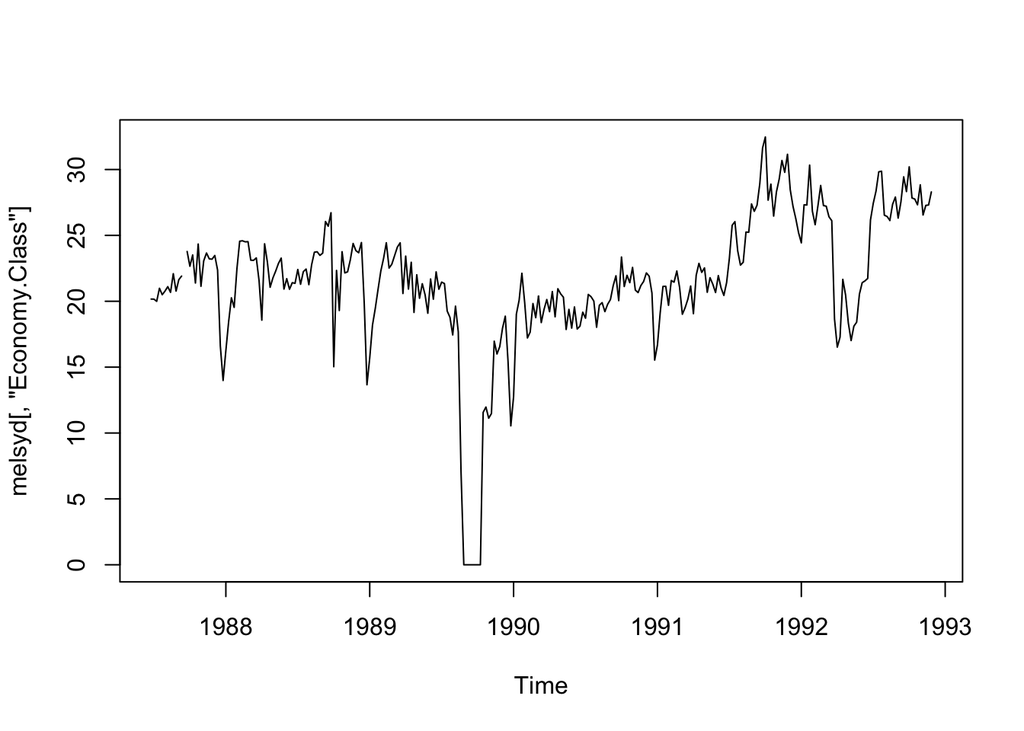

```r
plot(melsyd[,"Economy.Class"])
```

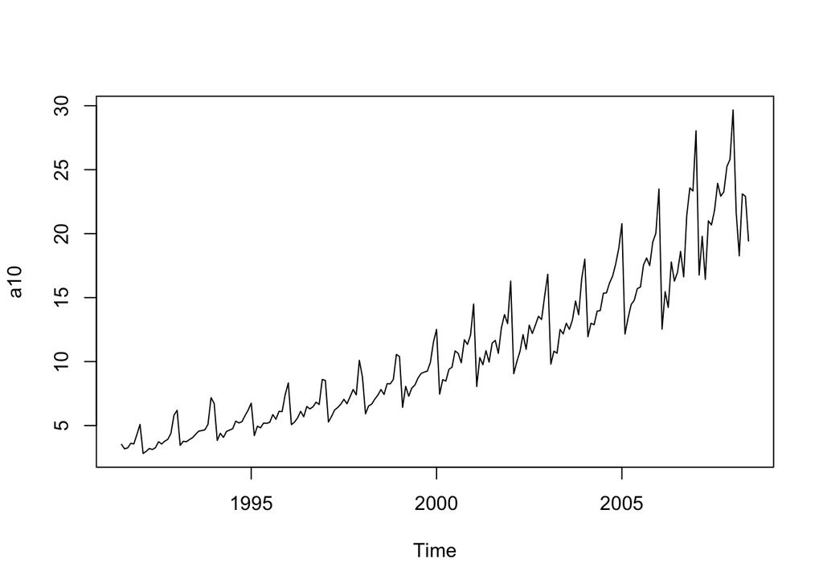

```r
plot(a10)
```

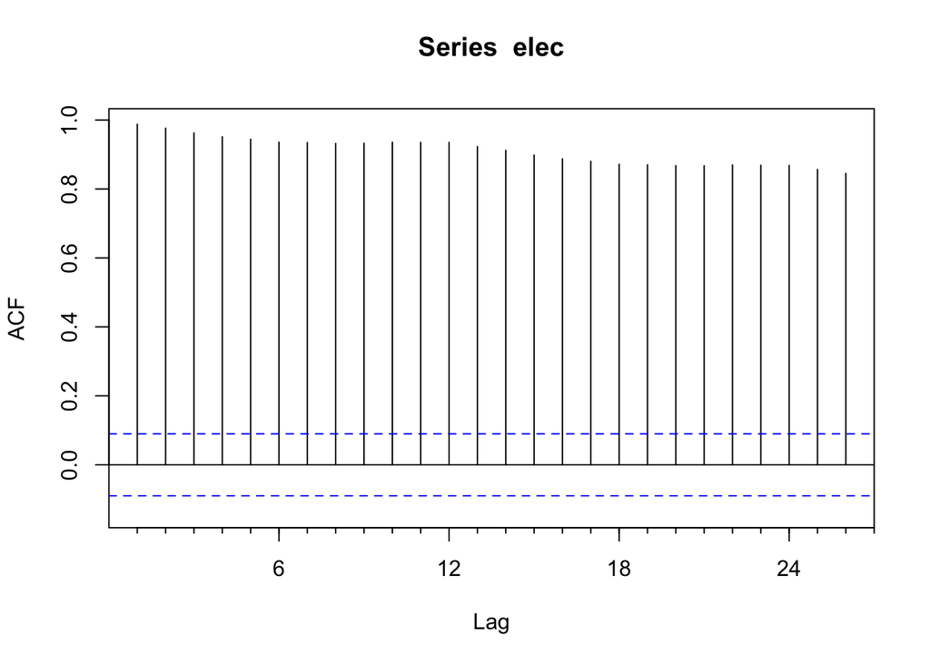

```r
Acf(elec)
```

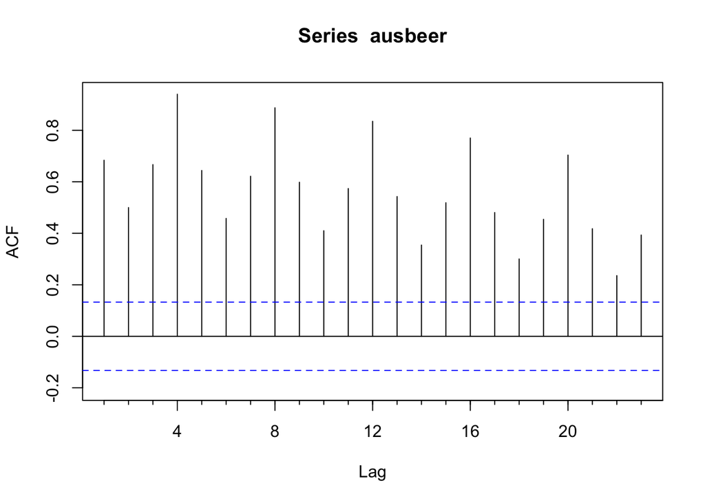

```r
Acf(ausbeer)
```

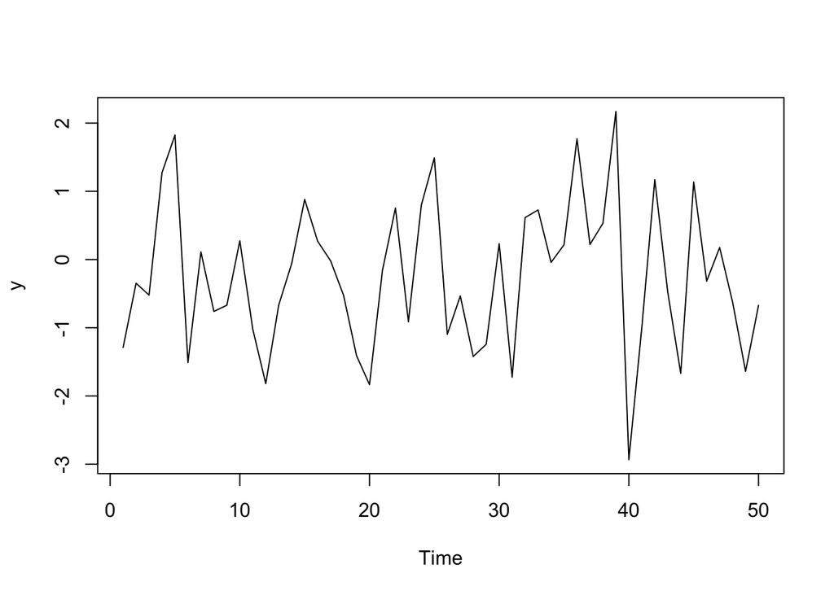

```r
# Random Plot

set.seed(30)
y <- ts(rnorm(50))
plot(y)
```

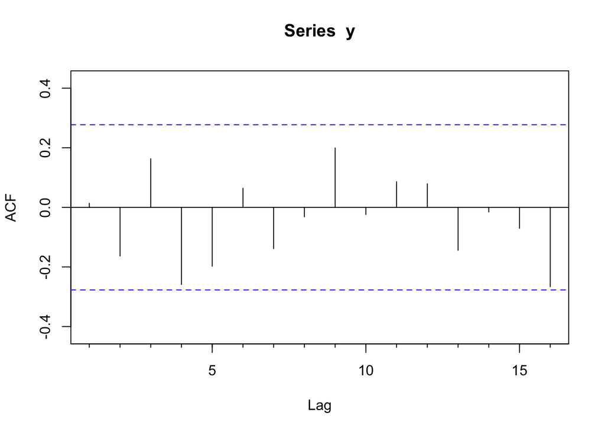

```r
Acf(y)
```

```r
# Residuals

tmp <- HoltWinters(ausbeer)
attributes(tmp)
```

```
## $names
## [1] "fitted"       "x"            "alpha"        "beta"         "gamma"
## [6] "coefficients" "seasonal"     "SSE"          "call"
##
## $class
## [1] "HoltWinters"
```

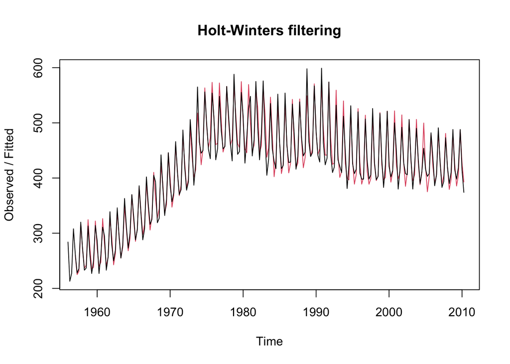

```r
plot(tmp)
```

```r
tmp_f <- forecast(tmp)
attributes(tmp_f)
```

```
## $names
##  [1] "method"    "model"     "level"     "mean"      "lower"     "upper"
##  [7] "x"         "series"    "fitted"    "residuals"
##
## $class
## [1] "forecast"
```

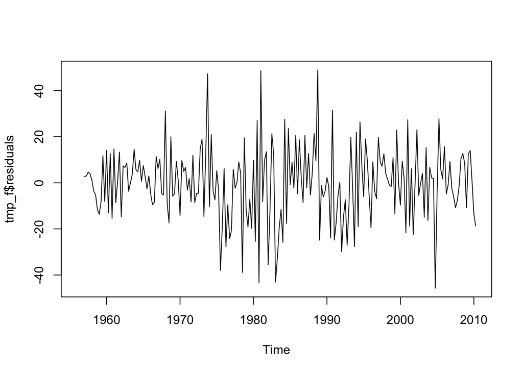

```r
plot(tmp_f$residuals)
```

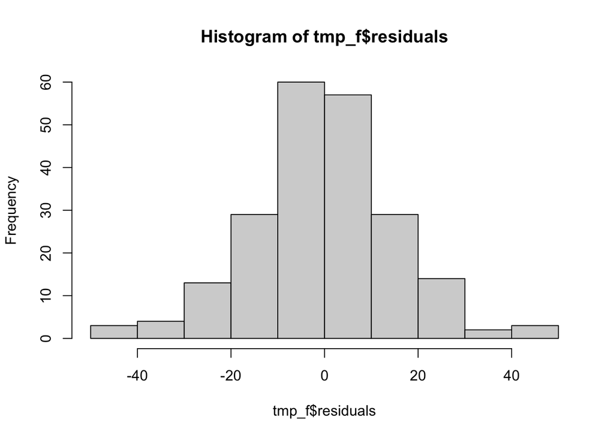

```r
hist(tmp_f$residuals)
```

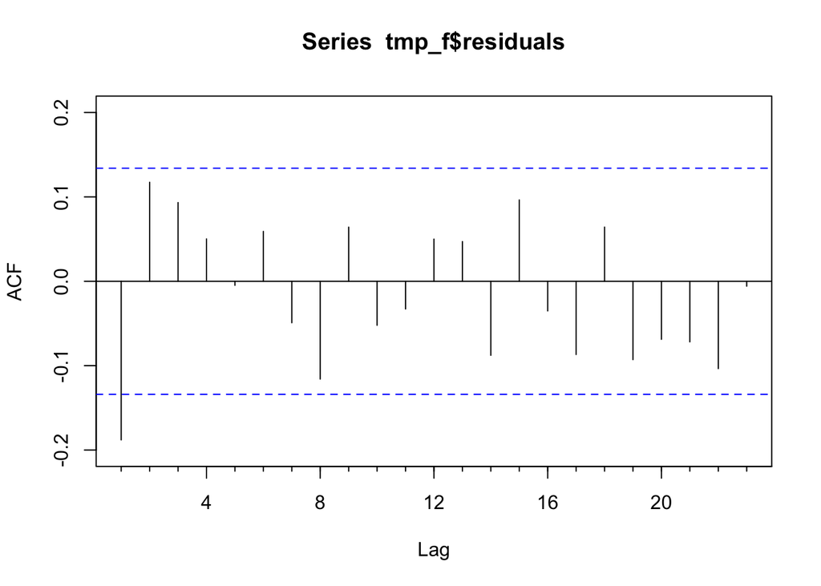

```r
Acf(tmp_f$residuals)
```

```r
accuracy(tmp_f)
```

```
##                      ME     RMSE      MAE        MPE     MAPE      MASE
## Training set -0.3702353 15.86279 12.15598 -0.1241059 2.874404 0.7837843
##                    ACF1
## Training set -0.1879524
```